# Projet Data Mining

# **Partie 1 :Présentation des données - Wine Dataset :**

-Plateforme : UC Irvine Machine Learning Repository

-Source : The Institute of Pharmaceutical and Food Analysis and Technologies

-Objets : vins provenant de 3 cultivars différents, 13 attributs (valeurs continues)

-Problème posé : classification

-Attributs déterministes ?

```r
library(ggplot2)
library(plyr)
library(caret)
library(reshape2)
library(MASS)
library(ggcorrplot)
library(caret)

#Decision tree package
library(rpart)
library(rpart.plot)
library(e1071)
library(class)
```

```r
data = read.csv("/home/ucp/Téléchargements/projet_Data_Mining/wine.data", header = FALSE)
str(data)
```

```
## 'data.frame':    178 obs. of  14 variables:
##  $ V1 : int  1 1 1 1 1 1 1 1 1 1 ...
##  $ V2 : num  14.2 13.2 13.2 14.4 13.2 ...
##  $ V3 : num  1.71 1.78 2.36 1.95 2.59 1.76 1.87 2.15 1.64 1.35 ...
##  $ V4 : num  2.43 2.14 2.67 2.5 2.87 2.45 2.45 2.61 2.17 2.27 ...
##  $ V5 : num  15.6 11.2 18.6 16.8 21 15.2 14.6 17.6 14 16 ...
##  $ V6 : int  127 100 101 113 118 112 96 121 97 98 ...
##  $ V7 : num  2.8 2.65 2.8 3.85 2.8 3.27 2.5 2.6 2.8 2.98 ...
##  $ V8 : num  3.06 2.76 3.24 3.49 2.69 3.39 2.52 2.51 2.98 3.15 ...
##  $ V9 : num  0.28 0.26 0.3 0.24 0.39 0.34 0.3 0.31 0.29 0.22 ...
##  $ V10: num  2.29 1.28 2.81 2.18 1.82 1.97 1.98 1.25 1.98 1.85 ...
##  $ V11: num  5.64 4.38 5.68 7.8 4.32 6.75 5.25 5.05 5.2 7.22 ...
##  $ V12: num  1.04 1.05 1.03 0.86 1.04 1.05 1.02 1.06 1.08 1.01 ...
##  $ V13: num  3.92 3.4 3.17 3.45 2.93 2.85 3.58 3.58 2.85 3.55 ...
##  $ V14: int  1065 1050 1185 1480 735 1450 1290 1295 1045 1045 ...
```

```r
colnames(data) <- c("type","alcohol", "malic_acid","ash",
                   "alcalinity_of_ash","magnesium","total_phenols",
                   "flavanoids","nonflavanoid_phenol",
                   "proanthocyanins","color_intensity","hue","id_of_diluted_wine","proline")
```

```r
# statistiques de chaque colonnes
summary(data)
```

```
##       type          alcohol        malic_acid         ash
##  Min.   :1.000   Min.   :11.03   Min.   :0.740   Min.   :1.360
##  1st Qu.:1.000   1st Qu.:12.36   1st Qu.:1.603   1st Qu.:2.210
##  Median :2.000   Median :13.05   Median :1.865   Median :2.360
##  Mean   :1.938   Mean   :13.00   Mean   :2.336   Mean   :2.367
##  3rd Qu.:3.000   3rd Qu.:13.68   3rd Qu.:3.083   3rd Qu.:2.558
##  Max.   :3.000   Max.   :14.83   Max.   :5.800   Max.   :3.230
##  alcalinity_of_ash   magnesium      total_phenols     flavanoids
##  Min.   :10.60     Min.   : 70.00   Min.   :0.980   Min.   :0.340
##  1st Qu.:17.20     1st Qu.: 88.00   1st Qu.:1.742   1st Qu.:1.205
##  Median :19.50     Median : 98.00   Median :2.355   Median :2.135
##  Mean   :19.49     Mean   : 99.74   Mean   :2.295   Mean   :2.029
##  3rd Qu.:21.50     3rd Qu.:107.00   3rd Qu.:2.800   3rd Qu.:2.875
##  Max.   :30.00     Max.   :162.00   Max.   :3.880   Max.   :5.080
##  nonflavanoid_phenol proanthocyanins color_intensity       hue
##  Min.   :0.1300      Min.   :0.410   Min.   : 1.280   Min.   :0.4800
##  1st Qu.:0.2700      1st Qu.:1.250   1st Qu.: 3.220   1st Qu.:0.7825
##  Median :0.3400      Median :1.555   Median : 4.690   Median :0.9650
##  Mean   :0.3619      Mean   :1.591   Mean   : 5.058   Mean   :0.9574
##  3rd Qu.:0.4375      3rd Qu.:1.950   3rd Qu.: 6.200   3rd Qu.:1.1200
##  Max.   :0.6600      Max.   :3.580   Max.   :13.000   Max.   :1.7100
##  id_of_diluted_wine    proline
##  Min.   :1.270      Min.   : 278.0
##  1st Qu.:1.938      1st Qu.: 500.5
##  Median :2.780      Median : 673.5
##  Mean   :2.612      Mean   : 746.9
##  3rd Qu.:3.170      3rd Qu.: 985.0
##  Max.   :4.000      Max.   :1680.0
```

```r
# check for missing values
for (i in colnames(data)){
  print(paste(i,':', sum(is.na(data[[i]])),'missing values'))
}
```

```
## [1] "type : 0 missing values"
## [1] "alcohol : 0 missing values"
## [1] "malic_acid : 0 missing values"
## [1] "ash : 0 missing values"
## [1] "alcalinity_of_ash : 0 missing values"
## [1] "magnesium : 0 missing values"
## [1] "total_phenols : 0 missing values"
## [1] "flavanoids : 0 missing values"
## [1] "nonflavanoid_phenol : 0 missing values"
## [1] "proanthocyanins : 0 missing values"
## [1] "color_intensity : 0 missing values"
## [1] "hue : 0 missing values"
## [1] "id_of_diluted_wine : 0 missing values"
## [1] "proline : 0 missing values"
```

```r
#check distinct values
#reminder : 178 objects
for (i in colnames(data)){
  print(paste(i,':', length(unique(data[[i]])),'distinct values'))
}
```

```
## [1] "type : 3 distinct values"
## [1] "alcohol : 126 distinct values"
## [1] "malic_acid : 133 distinct values"
## [1] "ash : 79 distinct values"
## [1] "alcalinity_of_ash : 63 distinct values"
## [1] "magnesium : 53 distinct values"
## [1] "total_phenols : 97 distinct values"
## [1] "flavanoids : 132 distinct values"
## [1] "nonflavanoid_phenol : 39 distinct values"
## [1] "proanthocyanins : 101 distinct values"
## [1] "color_intensity : 132 distinct values"
## [1] "hue : 78 distinct values"
## [1] "id_of_diluted_wine : 122 distinct values"
## [1] "proline : 121 distinct values"
```

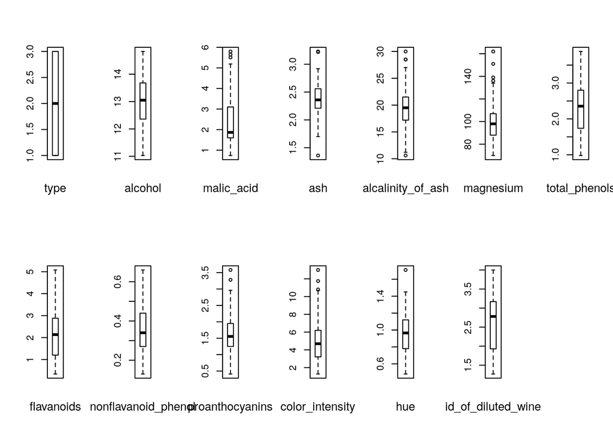

```r
oldpar = par(mfrow = c(2,7))
for ( i in 1:13 ) {
  boxplot(data[[i]])
  mtext(names(data)[i], cex = 0.8, side = 1, line = 2)
}
par(oldpar)
```

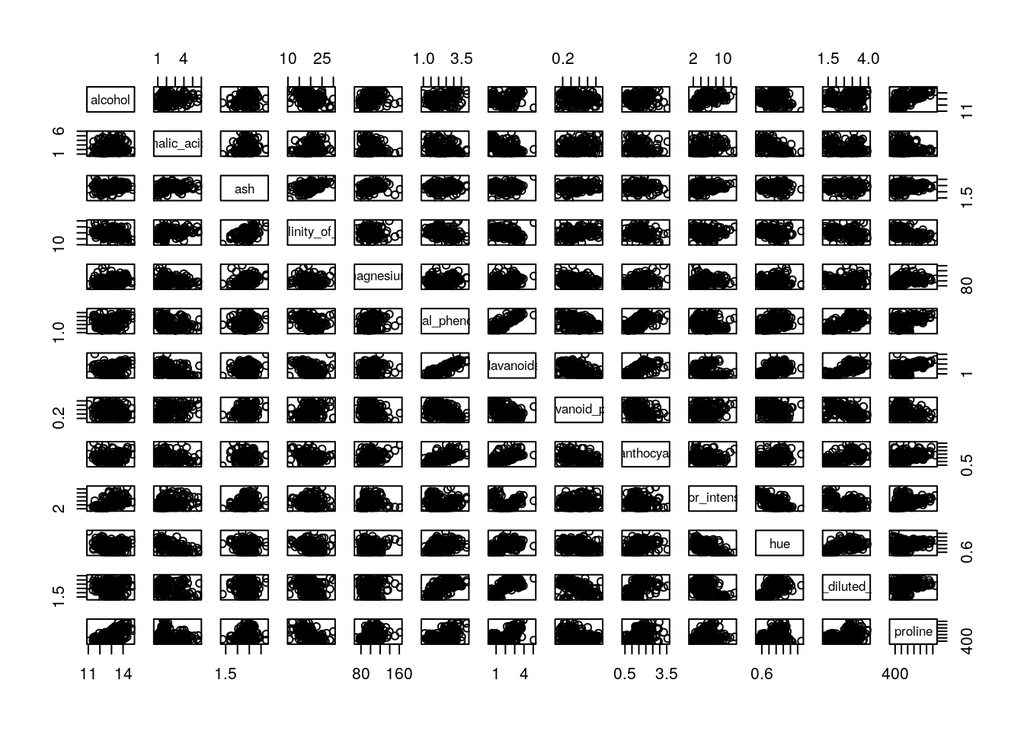

```r
par(oldpar)
pairs(data[, -grep("type", colnames(data))])
```

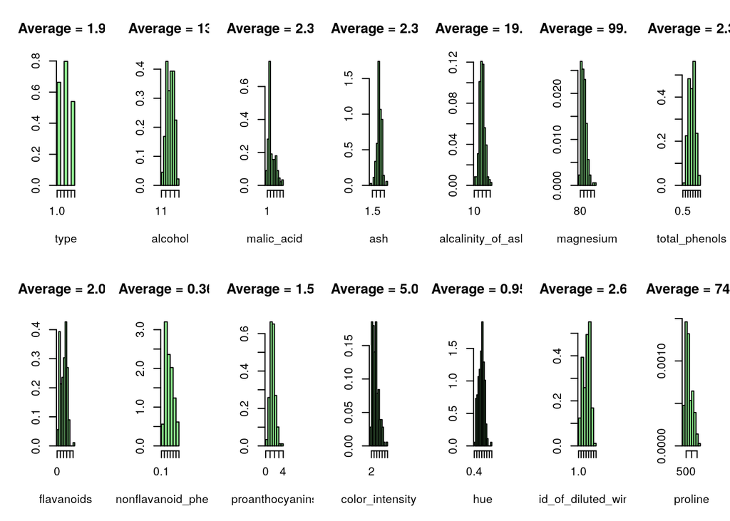

```r
oldpar = par(mfrow = c(2,7))
for ( i in 1:14 ) {
  truehist(data[[i]], xlab = names(data)[i], col = 'lightgreen', main = paste("Average =", signif(mean(data[[i]]),3)))
}
```

```r
data$type <- as.factor(data$type)

str(data)
```

```
## 'data.frame':    178 obs. of  14 variables:
##  $ type               : Factor w/ 3 levels "1","2","3": 1 1 1 1 1 1 1 1 1 1 ...
##  $ alcohol            : num  14.2 13.2 13.2 14.4 13.2 ...
##  $ malic_acid         : num  1.71 1.78 2.36 1.95 2.59 1.76 1.87 2.15 1.64 1.35 ...
##  $ ash                : num  2.43 2.14 2.67 2.5 2.87 2.45 2.45 2.61 2.17 2.27 ...
##  $ alcalinity_of_ash  : num  15.6 11.2 18.6 16.8 21 15.2 14.6 17.6 14 16 ...
##  $ magnesium          : int  127 100 101 113 118 112 96 121 97 98 ...
##  $ total_phenols      : num  2.8 2.65 2.8 3.85 2.8 3.27 2.5 2.6 2.8 2.98 ...
##  $ flavanoids         : num  3.06 2.76 3.24 3.49 2.69 3.39 2.52 2.51 2.98 3.15 ...
##  $ nonflavanoid_phenol: num  0.28 0.26 0.3 0.24 0.39 0.34 0.3 0.31 0.29 0.22 ...
##  $ proanthocyanins    : num  2.29 1.28 2.81 2.18 1.82 1.97 1.98 1.25 1.98 1.85 ...
##  $ color_intensity    : num  5.64 4.38 5.68 7.8 4.32 6.75 5.25 5.05 5.2 7.22 ...
##  $ hue                : num  1.04 1.05 1.03 0.86 1.04 1.05 1.02 1.06 1.08 1.01 ...
##  $ id_of_diluted_wine : num  3.92 3.4 3.17 3.45 2.93 2.85 3.58 3.58 2.85 3.55 ...
##  $ proline            : int  1065 1050 1185 1480 735 1450 1290 1295 1045 1045 ...
```

# **Partie 2 :Analyse des données - attribut déterministe**

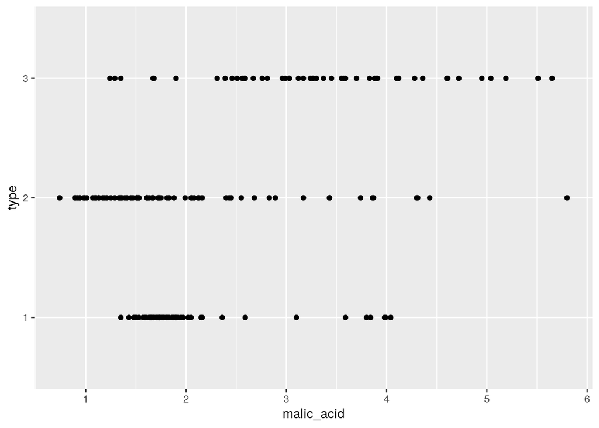

```r
###### on observe qu'un alcohol < 12.3 est forcement de type 2, cela pourrait aider l'arbre de décision
qplot(malic_acid, type, data = data)
```

[output not shown]

[output not shown]

Ici on peut conjecturer que les acides maliques > 4.5 sont de type 3 malgré la présence d’un outlier de type2, On émet plus de réserve sur la pertinence de cet attribut

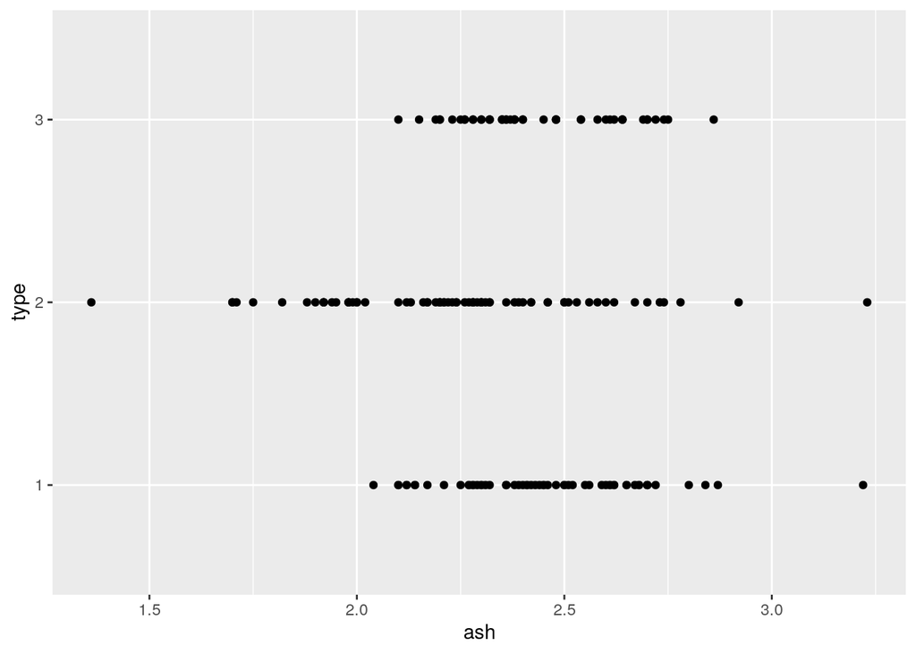

```r
qplot(ash, type, data = data)
```

Ici on peut observer qu’un taux d’ash < 2.0 permet d’identifier des types 2, peut être utile pour détecter ce type cependant il n’est pas un bon indicateur pour les 2 autres types

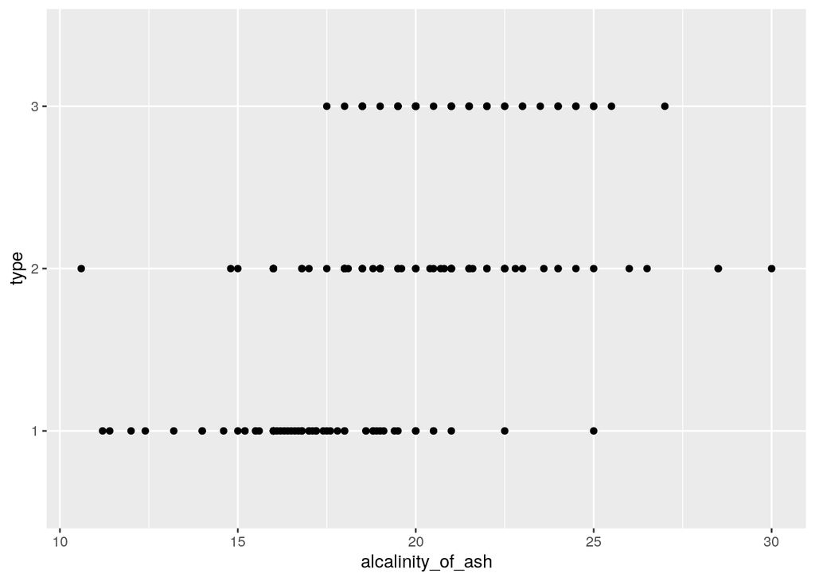

```r
qplot(alcalinity_of_ash, type, data = data)
```

alcalinity of ash pourrait nous aider à identifier quelques alcohols du type 1 mais reste trop commun aux autres types

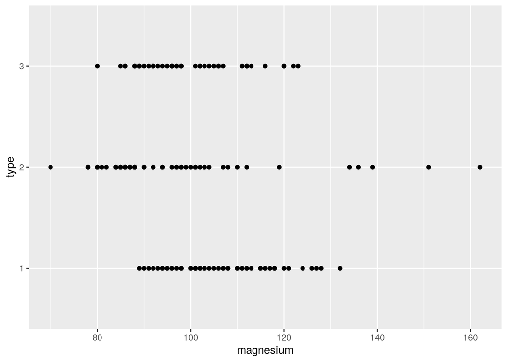

```r
qplot(magnesium, type, data = data)
```

la grande majorité des valeurs de magnesium se trouvent dans l’itnervalle [80,130] et ne permet pas de prendre de décision. Cet attribut est très sûrement à écarter

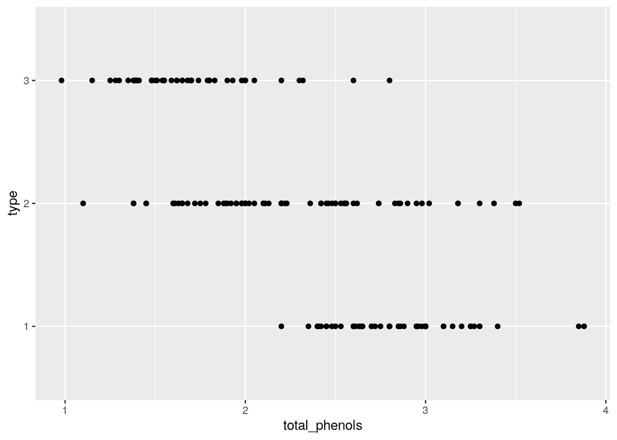

```r
qplot(total_phenols, type, data = data)
```

cet attribut est plutôt bien réparti pour prendre une décision pour les types 1 et 3, et on a vu précedemment que le type 2 était identifiable par 2 autres attributs

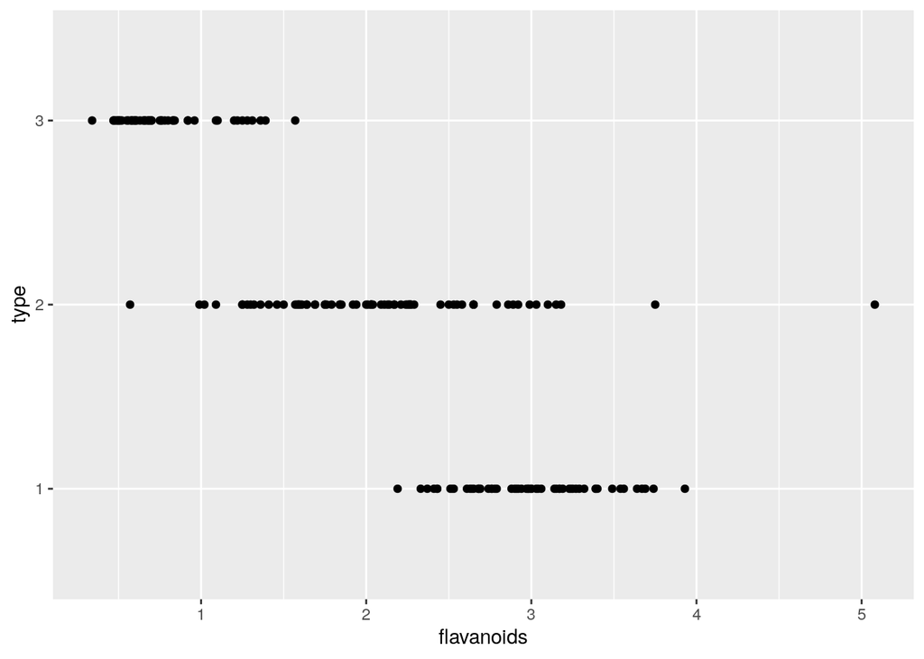

```r
qplot(flavanoids, type, data = data)
```

là encore cet attribut sépare bien les types 1 et 3

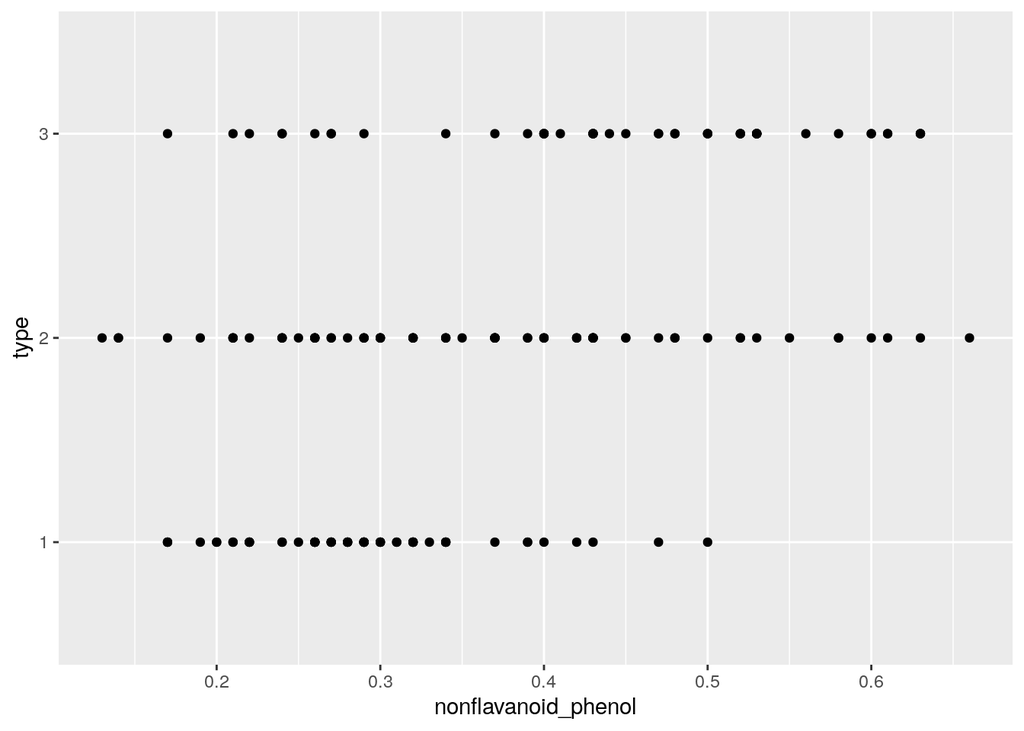

```r
qplot(nonflavanoid_phenol, type, data = data)
```

nonflavanoid_phenol ne permet pas d’identifier correctement les types, trop commun

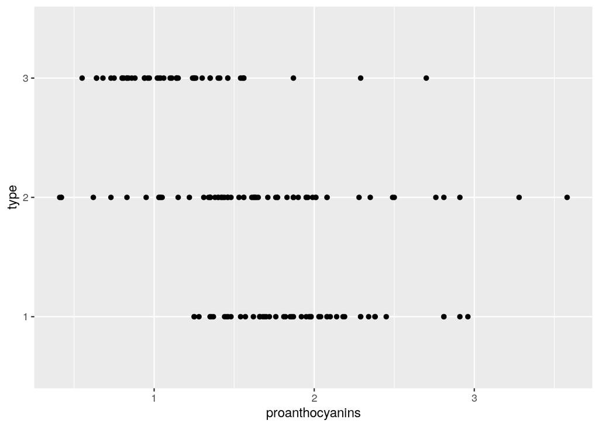

```r
qplot(proanthocyanins, type, data = data)
```

Cet attribut peut permettre de trancher entre type 1/3

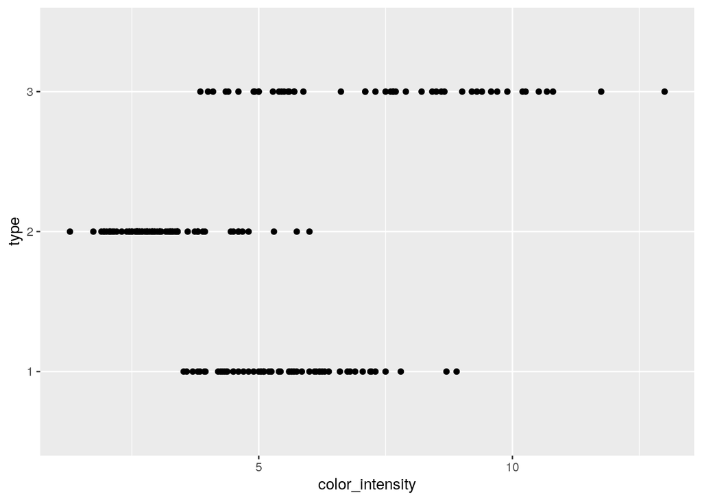

```r
qplot(color_intensity, type, data = data)
```

cet attribut donne une bonne indication pour le type 2

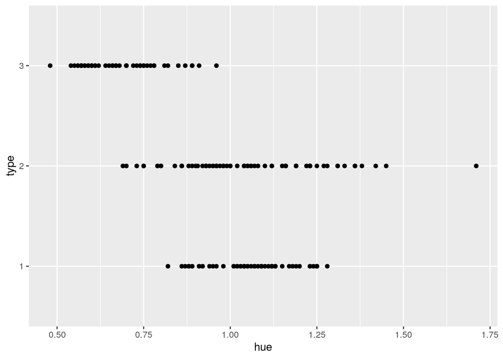

```r
qplot(hue, type, data = data)
```

Cet attribut peut permettre de trancher entre les 3 types même s’il est pas très réparti

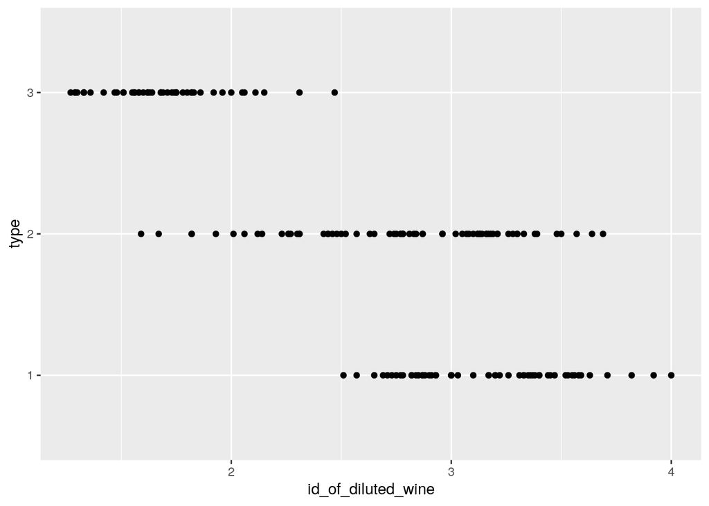

```r
qplot(id_of_diluted_wine, type, data = data)
```

Cet attribut découpe parfaitement les type 1 et 3

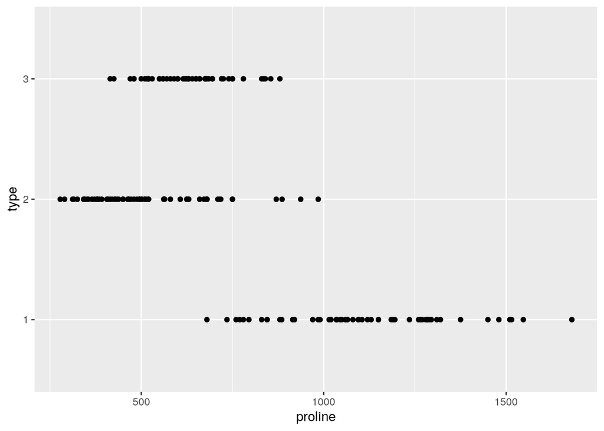

```r
qplot(proline, type, data = data)
```

# Après l’analyse sur les différents attributs, nous retenons color_intensity, flavanoids, id_of_diluted_wine et proline comme attributs pour la décision

```r
### nous retenons color_intensity, flavanoids, id_of_diluted_wine, proline comme attributs pour la décision
data2 <- subset(data, select=c("type", "color_intensity", "flavanoids", "id_of_diluted_wine","proline" ))
data2
```

|  | type | color_intensity | flavanoids | id_of_diluted_wine | proline |
| --- | --- | --- | --- | --- | --- |
| 1 | 1 | 5.640000 | 3.06 | 3.92 | 1065 |
| 2 | 1 | 4.380000 | 2.76 | 3.40 | 1050 |
| 3 | 1 | 5.680000 | 3.24 | 3.17 | 1185 |
| 4 | 1 | 7.800000 | 3.49 | 3.45 | 1480 |
| 5 | 1 | 4.320000 | 2.69 | 2.93 | 735 |
| 6 | 1 | 6.750000 | 3.39 | 2.85 | 1450 |
| 7 | 1 | 5.250000 | 2.52 | 3.58 | 1290 |
| 8 | 1 | 5.050000 | 2.51 | 3.58 | 1295 |
| 9 | 1 | 5.200000 | 2.98 | 2.85 | 1045 |
| 10 | 1 | 7.220000 | 3.15 | 3.55 | 1045 |

[output cut: 168 more lines]

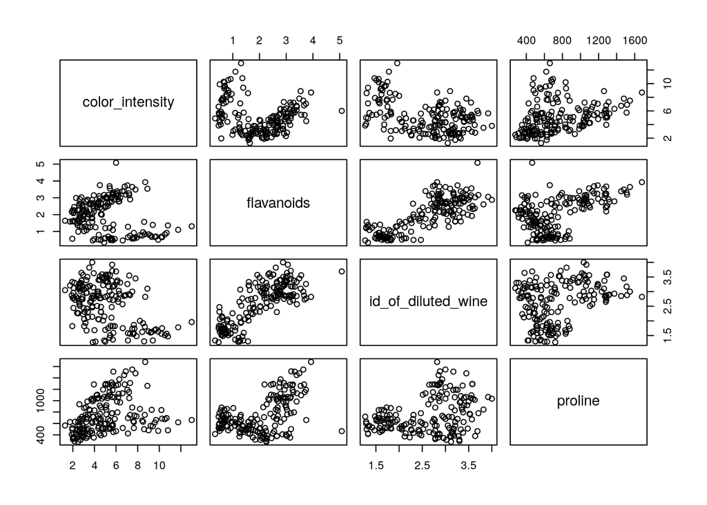

```r
pairs(data2[, -grep("type", colnames(data2))])
```

# **Partie 3 :ARBRE DE DECISION**

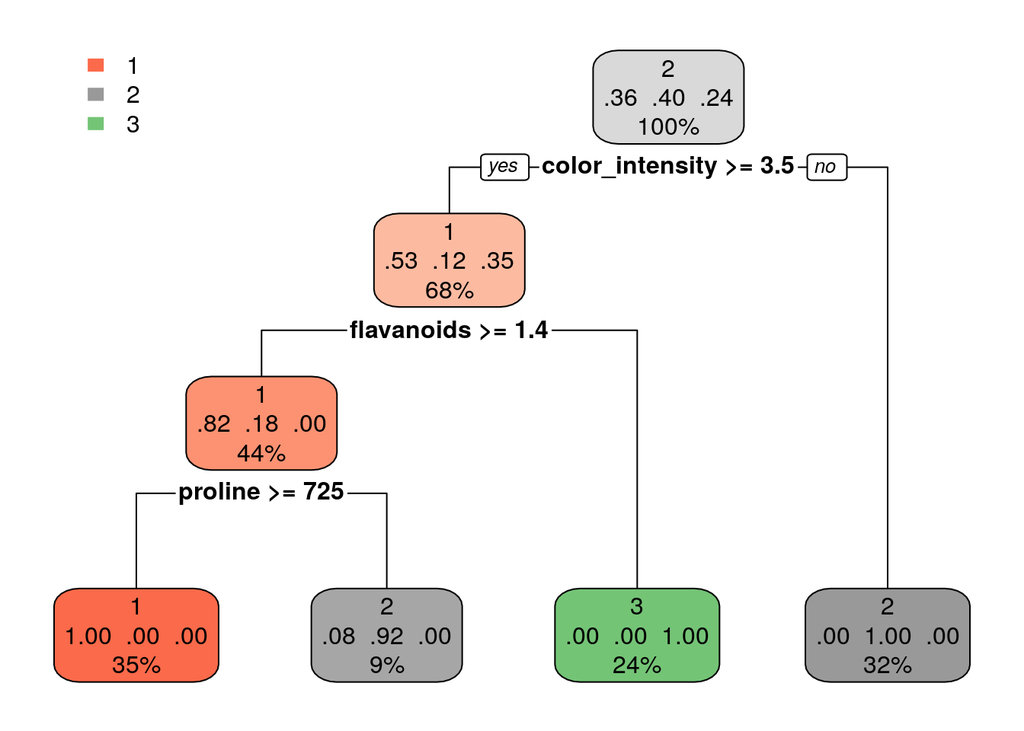

```r
set.seed(12345)
ind <- sample(2, nrow(data2), replace=TRUE, prob=c(0.8, 0.2))
data_train  <- data2[ind==1,]
data_test  <- data2[ind==2,]

fit <- rpart(type~., data = data_train, method = 'class')
rpart.plot(fit, extra = 104)
```

```r
predict_unseen <-predict(fit, data_test, type = 'class')

table_mat <- table(data_test$type, predict_unseen)
table_mat
```

```
##    predict_unseen
##      1  2  3
##   1 10  0  0
##   2  0 16  1
##   3  0  1 14
```

```r
accuracy_Test <- sum(diag(table_mat)) / sum(table_mat)
print(paste('Accuracy for test', accuracy_Test))
```

```
## [1] "Accuracy for test 0.952380952380952"
```

```r
accuracy_tune <- function(fit) {
  predict_unseen <- predict(fit, data_test, type = 'class')
  table_mat <- table(data_test$type, predict_unseen)
  accuracy_Test <- sum(diag(table_mat)) / sum(table_mat)
  accuracy_Test
}

control <- rpart.control(minsplit = 4,
                         minbucket = round(5 / 3),
                         maxdepth = 3,
                         cp = 0)
tune_fit <- rpart(type~., data = data_train, method = 'class', control = control)
accuracy_tune(tune_fit)
```

```
## [1] 0.952381
```

# **Partie 4 : kNN classifier using caret**

```r
# Configuration des commandes de train
repeats = 3
numbers = 10
tunel = 20


df_knn <- createDataPartition(data2$type, p = 0.8, list = FALSE)
df_knn
```

[output not shown]

[output cut: 130 more lines]

```r
df2_train <- data2[df_knn, ]
df2_test <- data2[-df_knn, ]

trainCtrl <- trainControl(method = "repeatedcv", number = numbers, repeats = repeats)
#KNN en utilisant la méthode du train fret caret
model_knn <- train(type ~., data = df2_train, method = "knn",
                   trControl = trainCtrl,
                   preProcess = c("center", "scale"),
                   tuneLength = tunel )
model_knn
```

```
## k-Nearest Neighbors
##
## 144 samples
##   4 predictor
##   3 classes: '1', '2', '3'
##
## Pre-processing: centered (4), scaled (4)
## Resampling: Cross-Validated (10 fold, repeated 3 times)
## Summary of sample sizes: 129, 129, 130, 130, 130, 129, ...
## Resampling results across tuning parameters:
##
##   k   Accuracy   Kappa
##    5  0.9607937  0.9408480
##    7  0.9607937  0.9407925
##    9  0.9587302  0.9377979
##   11  0.9611111  0.9414999
##   13  0.9633333  0.9446554
##   15  0.9631746  0.9443822
##   17  0.9631746  0.9443091
##   19  0.9607937  0.9406911
##   21  0.9584127  0.9370457
##   23  0.9514286  0.9265051
##   25  0.9585714  0.9372349
##   27  0.9538095  0.9300550
##   29  0.9514286  0.9262960
##   31  0.9538095  0.9298858
##   33  0.9560317  0.9330128
##   35  0.9490476  0.9223252
##   37  0.9468254  0.9189698
##   39  0.9468254  0.9189698
##   41  0.9490476  0.9223944
##   43  0.9585714  0.9370065
##
## Accuracy was used to select the optimal model using the largest value.
## The final value used for the model was k = 13.
```

# Graphique choix de k optimal

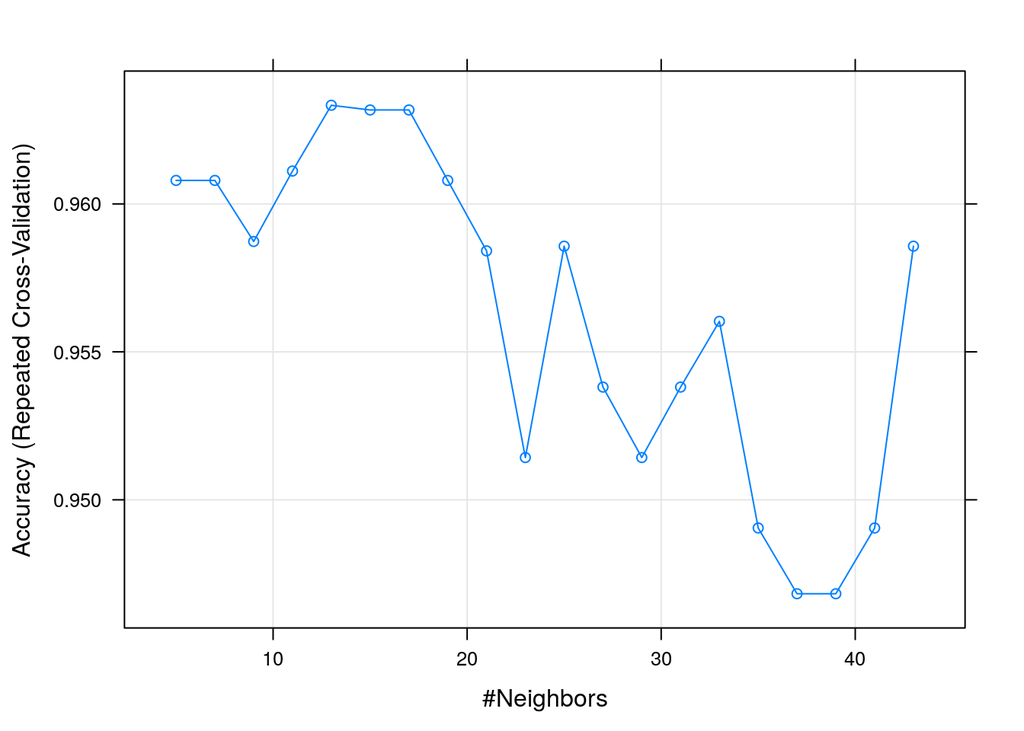

```r
plot(model_knn)
```

```r
varImp(model_knn)
```

```
## ROC curve variable importance
##
##   variables are sorted by maximum importance across the classes
##                        X1    X2     X3
## flavanoids         100.00 20.96 100.00
## id_of_diluted_wine 100.00 38.46 100.00
## proline             63.13 59.17  63.13
## color_intensity      0.00 51.45  51.45
```

# Prédiction

```r
prediction_knn <- predict(model_knn, newdata = df2_test)
confusionMatrix(prediction_knn, reference = df2_test$type)
```

```
## Confusion Matrix and Statistics
##
##           Reference
## Prediction  1  2  3
##          1 11  2  0
##          2  0 10  0
##          3  0  2  9
##
## Overall Statistics
##
##                Accuracy : 0.8824
##                  95% CI : (0.7255, 0.967)
##     No Information Rate : 0.4118
##     P-Value [Acc > NIR] : 1.675e-08
##
##                   Kappa : 0.8243
##
##  Mcnemar's Test P-Value : NA
##
## Statistics by Class:
##
##                      Class: 1 Class: 2 Class: 3
## Sensitivity            1.0000   0.7143   1.0000
## Specificity            0.9130   1.0000   0.9200
## Pos Pred Value         0.8462   1.0000   0.8182
## Neg Pred Value         1.0000   0.8333   1.0000
## Prevalence             0.3235   0.4118   0.2647
## Detection Rate         0.3235   0.2941   0.2647
## Detection Prevalence   0.3824   0.2941   0.3235
## Balanced Accuracy      0.9565   0.8571   0.9600
```